# Chapter4_Lab2

# Goal

Let’s first read in the table.

```r
#We are going to be using the PCA library so we need to load that up
library(PCAmixdata)

#read the table and display the head of the table
Dota_datamixed <- read.table("Dota_normalized_mixed.csv", header=TRUE, sep=",")
head(Dota_datamixed)
```

|  | GamesPlayed | GamesWon | GamesLeft | Ditches | Points | Kills | KillsPerMin | Deaths | Assists | CreepsKilled | CreepsDenied | NeutralsKilled | TowersDestroyed | RaxsDestroyed | TotalTime | SkillLevel | Gender |
| --- | --- | --- | --- | --- | --- | --- | --- | --- | --- | --- | --- | --- | --- | --- | --- | --- | --- |
| 1 | 0.141362916 | 0.140589569 | 0.150 | 0.33333333 | 0.3502400 | 0.095653273 | 0.2857143 | 0.111196138 | 0.122157604 | 0.104006703 | 0.069642450 | 0.080559441 | 0.136485967 | 0.132340053 | 0.259790976 | 1 | F |
| 2 | 0.020602219 | 0.022108844 | 0.000 | 0.00000000 | 0.2624290 | 0.015710555 | 0.3095238 | 0.026489287 | 0.021663274 | 0.012018230 | 0.011796857 | 0.010606061 | 0.018838908 | 0.020157756 | 0.039233310 | 1 | F |
| 3 | 0.000633914 | 0.000000000 | 0.000 | 0.00000000 | 0.2697428 | 0.000463314 | 0.2619048 | 0.001648222 | 0.000523408 | 0.000475358 | 0.000227739 | 0.000163170 | 0.000000000 | 0.000000000 | 0.001125171 | 0 | M |
| 4 | 0.031378764 | 0.033446712 | 0.125 | 0.05555556 | 0.4348863 | 0.045446887 | 0.6190476 | 0.026371556 | 0.027159058 | 0.037421680 | 0.042928718 | 0.033030303 | 0.050749712 | 0.031551271 | 0.057958981 | 1 | F |
| 5 | 0.000000000 | 0.000566893 | 0.000 | 0.00000000 | 0.2841999 | 0.000379075 | 0.6666667 | 0.000117730 | 0.000290782 | 0.000077900 | 0.000182191 | 0.000069900 | 0.000000000 | 0.000000000 | 0.000138579 | 0 | M |
| 6 | 0.006339144 | 0.004535147 | 0.000 | 0.00000000 | 0.2413425 | 0.005601887 | 0.3095238 | 0.008476572 | 0.005815644 | 0.005518986 | 0.003917103 | 0.007738928 | 0.002691273 | 0.005258545 | 0.013660191 | 0 | M |

# Grouping Numerical and Categorical

We then separate the data into categorical variables and numerical variables.

```r
#two sets numerical and categorical
Dota_Numerical <- Dota_datamixed[,1:15]
Dota_Numerical[1:10,]
```

|  | GamesPlayed | GamesWon | GamesLeft | Ditches | Points | Kills | KillsPerMin | Deaths | Assists | CreepsKilled | CreepsDenied | NeutralsKilled | TowersDestroyed | RaxsDestroyed | TotalTime |
| --- | --- | --- | --- | --- | --- | --- | --- | --- | --- | --- | --- | --- | --- | --- | --- |
| 1 | 0.141362916 | 0.140589569 | 0.150 | 0.33333333 | 0.3502400 | 0.095653273 | 0.2857143 | 0.111196138 | 0.122157604 | 0.104006703 | 0.069642450 | 0.080559441 | 0.136485967 | 0.132340053 | 0.259790976 |
| 2 | 0.020602219 | 0.022108844 | 0.000 | 0.00000000 | 0.2624290 | 0.015710555 | 0.3095238 | 0.026489287 | 0.021663274 | 0.012018230 | 0.011796857 | 0.010606061 | 0.018838908 | 0.020157756 | 0.039233310 |
| 3 | 0.000633914 | 0.000000000 | 0.000 | 0.00000000 | 0.2697428 | 0.000463314 | 0.2619048 | 0.001648222 | 0.000523408 | 0.000475358 | 0.000227739 | 0.000163170 | 0.000000000 | 0.000000000 | 0.001125171 |
| 4 | 0.031378764 | 0.033446712 | 0.125 | 0.05555556 | 0.4348863 | 0.045446887 | 0.6190476 | 0.026371556 | 0.027159058 | 0.037421680 | 0.042928718 | 0.033030303 | 0.050749712 | 0.031551271 | 0.057958981 |
| 5 | 0.000000000 | 0.000566893 | 0.000 | 0.00000000 | 0.2841999 | 0.000379075 | 0.6666667 | 0.000117730 | 0.000290782 | 0.000077900 | 0.000182191 | 0.000069900 | 0.000000000 | 0.000000000 | 0.000138579 |
| 6 | 0.006339144 | 0.004535147 | 0.000 | 0.00000000 | 0.2413425 | 0.005601887 | 0.3095238 | 0.008476572 | 0.005815644 | 0.005518986 | 0.003917103 | 0.007738928 | 0.002691273 | 0.005258545 | 0.013660191 |
| 7 | 0.005071315 | 0.003968254 | 0.000 | 0.00000000 | 0.2110585 | 0.002990481 | 0.2380952 | 0.008241111 | 0.003634778 | 0.002255936 | 0.000910954 | 0.000955711 | 0.000768935 | 0.004382121 | 0.009453902 |
| 8 | 0.006656101 | 0.006235828 | 0.000 | 0.05555556 | 0.2667610 | 0.005475529 | 0.3571429 | 0.007652461 | 0.006106426 | 0.004608555 | 0.004531997 | 0.010652681 | 0.006920415 | 0.006134969 | 0.012164932 |
| 9 | 0.000633914 | 0.001133787 | 0.000 | 0.00000000 | 0.2697428 | 0.000758150 | 0.3571429 | 0.001000706 | 0.000872347 | 0.000410903 | 0.000705990 | 0.001818182 | 0.001922338 | 0.001752848 | 0.001348761 |
| 10 | 0.066561014 | 0.047619048 | 0.125 | 0.05555556 | 0.2159248 | 0.043551512 | 0.2619048 | 0.091770662 | 0.053125909 | 0.036226571 | 0.019562742 | 0.055011655 | 0.040753556 | 0.028921998 | 0.125944348 |

```r
Dota_Categorical <- Dota_datamixed[,16:17]
Dota_Categorical$SkillLevel <- as.factor(Dota_Categorical$SkillLevel)
Dota_Categorical[1:10,]
```

|  | SkillLevel | Gender |
| --- | --- | --- |
| 1 | 1 | F |
| 2 | 1 | F |
| 3 | 0 | M |
| 4 | 1 | F |
| 5 | 0 | M |
| 6 | 0 | M |
| 7 | 1 | M |
| 8 | 1 | M |
| 9 | 0 | M |
| 10 | 0 | F |

# Run PCAmix

We first run the PCAmix and then look at the Eigen vectors on the dimensions. Once you see that, you can see that 5-6 dimensions explains most of the variance, with 90% at dim =7 and 86% at dim=6. So we chose 6 dimensions.

Similar with PCA, we can also get the variables in the new coordinates as shown in the code below.

```r
#PCAmix
Dota_PCAmix <- PCAmix(X.quanti = Dota_Numerical, X.quali = Dota_Categorical, ndim=6, graph=FALSE)

#eigen vectors and their variance
Dota_PCAmix $eig
```

```
##          Eigenvalue   Proportion Cumulative
## dim 1  11.936694605 59.683473025   59.68347
## dim 2   1.256104449  6.280522243   65.96400
## dim 3   1.132914150  5.664570752   71.62857
## dim 4   1.052016346  5.260081732   76.88865
## dim 5   1.008849501  5.044247504   81.93290
## dim 6   0.983613360  4.918066802   86.85096
## dim 7   0.726694128  3.633470639   90.48443
## dim 8   0.563471180  2.817355900   93.30179
## dim 9   0.472164176  2.360820878   95.66261
## dim 10  0.412728693  2.063643463   97.72625
## dim 11  0.192267945  0.961339724   98.68759
## dim 12  0.115582587  0.577912933   99.26551
## dim 13  0.072075015  0.360375073   99.62588
## dim 14  0.026052443  0.130262217   99.75614
## dim 15  0.018349291  0.091746454   99.84789
## dim 16  0.011084586  0.055422932   99.90331
## dim 17  0.008946678  0.044733391   99.94805
## dim 18  0.006916682  0.034583411   99.98263
## dim 19  0.002340852  0.011704261   99.99433
## dim 20  0.001133333  0.005666667  100.00000
```

```r
#variables in the new coordinates
head(Dota_PCAmix$ind$coord )
```

```
##       dim 1       dim 2        dim 3      dim 4      dim 5      dim 6
## 1  5.447351  0.06944633 -0.835622225  1.0939335 -1.1350785  0.9525152
## 2 -0.498361  0.54430982 -0.003740209  0.4780487 -1.0073163  0.7902691
## 3 -1.628336 -0.56028928  0.213909334 -0.3576293  0.5643022 -0.5678549
## 4  1.276827  2.65932276  0.373191438  0.3329870 -0.6055787  0.7223375
## 5 -1.399876  1.18663202  0.309945777 -0.7977182  0.6957196 -0.6690671
## 6 -1.389392 -0.58845827  0.118583835 -0.4620245  0.4835475 -0.5738801
```

# Plotting

This plot will plot the link between the variables and the principle components. As you can see, almost all numerical variables except `KillsPerMin` and `Points` are linked to the first component (shown as Dim 1 in the graph). But `KillsPerMin` is almost orthogonal to the first component. `Skill Leve`l and `Points` are both linked to both second Principle Component and the first one. We can further inspect the loadings to understand the values per variable for each new component.

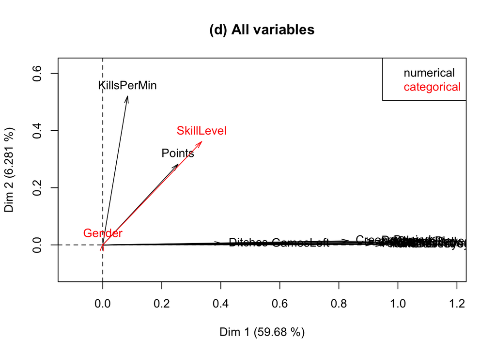

```r
#plotting all variables
plot(Dota_PCAmix ,choice="sqload",coloring.var=T, leg=TRUE, posleg="topright", main="(d) All variables")
```

# Loadings

We can also get the loadings for the quantitative and qualitative coordinates.

```r
Loadings_quant <- Dota_PCAmix $quanti.cor
Loadings_quant
```

```
##                     dim 1       dim 2       dim 3        dim 4
## GamesPlayed     0.9860079 -0.10100546 -0.03299740 -0.015293633
## GamesWon        0.9917422 -0.07052461 -0.01031608 -0.014395740
## GamesLeft       0.7403356  0.06263622 -0.13827016  0.001338181
## Ditches         0.6345757  0.07435245 -0.28609648  0.265831896
## Points          0.5050548  0.53152759  0.30811091  0.097530289
## Kills           0.9819449 -0.05116681  0.02765569 -0.036257042
## KillsPerMin     0.2901167  0.72154559  0.01883641 -0.181185327
## Deaths          0.9593566 -0.11704187 -0.06806024 -0.007017471
## Assists         0.9788078 -0.09828063 -0.02385677 -0.004247914
## CreepsKilled    0.9738698 -0.09568260  0.06202319 -0.062044466
## CreepsDenied    0.9126118 -0.11984260  0.15766756 -0.098885285
## NeutralsKilled  0.9587656 -0.08959743 -0.08257672 -0.006340284
## TowersDestroyed 0.9744077 -0.03792881  0.03744953 -0.031799903
## RaxsDestroyed   0.9737131 -0.03908052  0.05230679 -0.022225682
## TotalTime       0.9563001 -0.05666037 -0.10129192  0.033540952
##                        dim 5         dim 6
## GamesPlayed     -0.036976650  9.198358e-05
## GamesWon        -0.011407621 -1.303664e-02
## GamesLeft       -0.069614623  6.591781e-02
## Ditches          0.001078536  7.699657e-02
## Points           0.230184967 -3.927197e-02
## Kills            0.009726697 -2.666130e-02
## KillsPerMin      0.035470880 -3.624200e-02
## Deaths          -0.057399285  9.932600e-03
## Assists         -0.015293225 -1.003447e-02
## CreepsKilled    -0.005768580 -2.538603e-02
## CreepsDenied    -0.002338236 -4.221549e-02
## NeutralsKilled  -0.036813560  1.446276e-02
## TowersDestroyed  0.011072786 -2.011296e-02
## RaxsDestroyed    0.021758437 -2.043902e-02
## TotalTime       -0.034087746  1.528986e-02
```

```r
Loadings_qual <- Dota_PCAmix $categ.coord
Loadings_qual
```

```
##          dim 1       dim 2      dim 3        dim 4      dim 5       dim 6
## -1 -0.06067750 -2.25448154 -3.1592213 -11.64883938 13.0722349 23.30629037
## 0  -0.45200761 -0.57603983  0.2424422   0.07354874  0.1581203 -0.12338271
## 1   0.35155494  0.61925377 -0.4217944  -0.22414783 -0.4431336  0.09736369
## 2   1.74283957  0.69011627 -1.3865633   4.22797138  4.7128815 -0.62516411
## 3   2.88081804  0.44233715  6.9602662  -0.44896768  0.7960309  0.35674887
## F   0.02504610  0.07192003  0.2876448   0.80392970 -0.5770446  0.72965386
## M  -0.01494464 -0.04291361 -0.1716333  -0.47969286  0.3443139 -0.43537357
```

In conclusion, through this lab, you have seen how to apply PCA on a mixed categorical and numerical data types. You can then use the PCs as you did in Lab 1.